## Notas de aula de Mecânica Quântica Autor: Jonas Maziero

```python
%run init.ipynb
```

# Oscilador harmônico quântico 1D

O potencial harmônico clássico unidimensional, $U=kx^{2}/2$, correspondente à força restauradora $F_{x}=-\partial_{x}U=-kx$ (e usando $\omega=\sqrt{k/m}$), nos fornece, depois da quantização $x\rightarrow X$ e $p\rightarrow P$, o Hamiltoniano quântico para o oscilador harmônico quântico (OHQ) 1D: \begin{equation} H_{ohq} = \frac{P^{2}}{2m} + \frac{m\omega^{2}X^{2}}{2}. \end{equation} Como $[X,P]\ne\mathbb{O}$, não parece ser trivial diagonalizar esse hamiltoniano. A seguir veremos como usar os operadores escada para encontrar os autovalores e autovetores de $H_{ohq}$.

## Operadores escada

Definimos os operadores escada como uma combinação linear dos operadores posição $X$ e momento linear $P$: \begin{equation} a := \sqrt{\frac{m\omega}{2\hbar}}\left(X + \frac{i}{m\omega}P\right) \Rightarrow a^{\dagger} := \sqrt{\frac{m\omega}{2\hbar}}\left(X - \frac{i}{m\omega}P\right). \end{equation}

Podemos manipular essas equações para obter: \begin{align} & X = \sqrt{\frac{\hbar}{2m\omega}}(a^{\dagger}+a), \\ & P = i\sqrt{\frac{\hbar m\omega}{2}}(a^{\dagger}-a). \end{align}

Aqui usaremos a relação canônica de comutação entre posição e momento linear, \begin{equation} [X,P]=i\hbar\mathbb{I}, \end{equation} para verificar que \begin{align} [a,a^{\dagger}] & = \frac{m\omega}{2\hbar}\left[X + \frac{i}{m\omega}P,X - \frac{i}{m\omega}P\right] \\ & = \frac{m\omega}{2\hbar}\left(\mathbb{0} - \frac{i}{m\omega}[X,P] + \frac{i}{m\omega}[P,X] + \mathbb{0}\right) \\ & = \frac{m\omega}{2\hbar}\frac{-2i}{m\omega}[X,P] = \frac{-i}{\hbar}i\hbar\mathbb{I} \\ & = \mathbb{I} \\ & =aa^{\dagger}-a^{\dagger}a. \end{align}

Assim, o Hamiltoniano fica escrito como \begin{align} H_{ohq} & = -\frac{\hbar m\omega}{2}(a^{\dagger}-a)(a^{\dagger}-a)/2m + \frac{m\omega^{2}}{2}\frac{\hbar}{2m\omega}(a^{\dagger}+a)(a^{\dagger}+a)\\ & = \frac{\hbar\omega}{4}\left(-(a^{\dagger})^{2}+a^{\dagger}a+aa^{\dagger}-a^{2} + (a^{\dagger})^{2}+a^{\dagger}a+aa^{\dagger}+a^{2}\right) \\ & = \frac{\hbar\omega}{2}(a^{\dagger}a+aa^{\dagger}) = \frac{\hbar\omega}{2}(a^{\dagger}a+\mathbb{I}+a^{\dagger}a) \\ & = \hbar\omega(N+\mathbb{I}/2), \end{align} onde definimos o *operador número*, que é Hermintiano, como: \begin{equation} N:=a^{\dagger}a. \end{equation}

## Diagonalização do Hamiltoniano

Vamos definir \begin{equation} N|n\rangle=n|n\rangle \end{equation} e obter os possíveis valores de $n$. Primeiramente usamos a positividade da norma de um vetor qualquer do espaço de Hilbert associado: \begin{align} &||a|n\rangle||^{2}\ge 0 \\ & \therefore\ 0\le(a|n\rangle,a|n\rangle)=(|n\rangle,a^{\dagger}a|n\rangle) =(|n\rangle,N|n\rangle) = n\langle n|n\rangle=n \\ & \Rightarrow\ n \ge 0. \end{align} OBS. Este resultado também poderia ser obtido notando-se que $N$ é um operador positivo, e portanto possui autovalores reais e não negativos.

A principal observação a ser feita na sequência é sobre a ação dos operadores escada nos autovetores de $N$, que também são autovetores de $H$. Começamos usando $[a,a^\dagger]=\mathbb{I}$ para escrever \begin{align} N(a|n\rangle) & = a^{\dagger}aa|n\rangle \\ & = (aa^{\dagger}-\mathbb{I})a|n\rangle \\ & = aa^{\dagger}a|n\rangle-a|n\rangle \\ & = aN|n\rangle-a|n\rangle \\ & = an|n\rangle-a|n\rangle \\ & = (n-1)(a|n\rangle). \end{align} Ou seja, $a|n\rangle$ também é autovetor de $N$, mas correspondente ao autovalor $n-1$. Note que o estado $|n-1\rangle$ é autovetor de $N$ correspondente a este mesmo autovalor, e portanto devemos ter \begin{equation} a|n\rangle\propto|n-1\rangle =: c|n-1\rangle. \end{equation}

Para que possam representar estados físicamente aceitáveis, esses vetores devem ser normalizados. Vem então que \begin{align} & \langle n| a^{\dagger}a|n\rangle = \langle n-1|c^{*}c|n-1\rangle, \\ & \langle n|N|n\rangle = |c|^{2}\langle n-1|n-1\rangle, \\ & n\langle n|n\rangle = n = |c|^{2} \\ & \Rightarrow\ |c|=\sqrt{n}, \end{align} que nos fornece a ação do operador de abaixamento na base número (assumimos $c\in\mathbb{R}$): \begin{equation} a|n\rangle = \sqrt{n}|n-1\rangle. \end{equation}

Já sabemos que $n\ge 0$ e que $a$ leva $|n\rangle$ em um autovetor de $N$ "diminuído por uma unidade". Podemos usar esses fatos para argumentar que $n$ deve ser inteiro. O menor valor possível de $n$ é $0$. Então se $a$ atua no autovetor $|n=0\rangle\equiv|0\rangle$, devemos obter um vetor que não é um estado possível, que é o vetor nulo, i.e., \begin{equation} a|0\rangle=|\oslash\rangle. \end{equation} Agora, se $n$ pudesse ser real, teríamos, por exemplo, $a|0.5\rangle=|-0.5\rangle$, que não é um valor possível de $n$. Concluímos então que $n\in\mathbb{Z}_{\ge 0}$.

Também pode-se mostrar que \begin{equation} a^{\dagger}|n\rangle = \sqrt{n+1}|n+1\rangle. \end{equation} Em contraste com $a$, $a^{\dagger}$ pode aumentar o autovalor $n$ indefinidamente. Não há argumento matemático impondo um limite superior para $n$. Resumindo \begin{align} & N|n\rangle=n|n\rangle \text{ com } n=0,1,2,3,\cdots, \\ & H_{ohq}|n\rangle = E_{n}|n\rangle=\hbar\omega(n+1/2)|n\rangle. \end{align} Vemos, no entanto, que há uma restrição física para o limite superior de $n$, e que é imposta pela energia máxima que o OHQ poderá ter. Além disso, a restrição $n\ge 0$ implica em uma energia mínima não nula dos OHQ, a chamada **energia de ponto zero**, que apresenta o fato que todo OHQ está sempre oscilando.

Abaixo está mostrado o diagrama de níveis de energia para o OHQ1D.

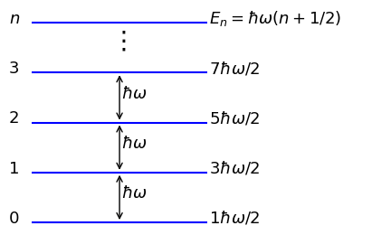

```python
import matplotlib
matplotlib.rcParams.update({'font.size':11})
plt.figure(figsize = (5,3), dpi = 100)
xmin = 0; xmax = 1
for j in range(0,5):
    plt.hlines(j,xmin,xmax,color='blue');
for j in range(0,4):
    plt.text(-0.13,j,j,color='black',fontsize=13)
    plt.text(1.01,j, str(2*j+1)+r'$\hbar\omega/2$',\
             color='black',fontsize=13)
for j in range(0,3):
    plt.annotate("", xy=(0.5,j), xytext=(0.5,j+1), \
                 arrowprops=dict(arrowstyle="<->"))
    plt.text(0.51,(2*j+1)/2,r'$\hbar\omega$',fontsize=13)
plt.text(0.45,3.5,r'$\vdots$',fontsize=20)
plt.text(-0.13,4,r'$n$',color='black',fontsize=13)
plt.text(1.01,4,r'$E_{n}=\hbar\omega(n+1/2)$',fontsize=13)
plt.axis('off'); plt.xlim(0,2); plt.ylim(-0.05,4.05);
plt.show()
```

## Autofunções do OHQ na base de posição

### Estado fundamental

Baseado na álgebra do OHQ, temos que \begin{align} & \langle x|a|0\rangle = \langle x|\oslash\rangle = 0 \\ & = \langle x|\sqrt{\frac{m\omega}{2\hbar}}\Big(X+\frac{i}{m\omega}P\Big)|0\rangle \\ & = \sqrt{\frac{m\omega}{2\hbar}}\Big(\langle x|X|0\rangle+\frac{i}{m\omega}\langle x|P|0\rangle\Big) \\ & = \sqrt{\frac{m\omega}{2\hbar}}\Big(x\langle x|0\rangle+\frac{i}{m\omega}\frac{\hbar}{i}\partial_x \langle x|0\rangle\Big) \\ & = \sqrt{\frac{m\omega}{2\hbar}}\Big(x\psi_0 (x)+\frac{i}{m\omega}\frac{\hbar}{i}\partial_x \psi_0 (x)\Big). \end{align} Portanto \begin{align} & \partial_x \psi_0 (x) = - \frac{m\omega x}{\hbar}\psi_0 (x) \\ & \therefore\ \psi_0 (x) = C e^{-m\omega x^2 /2\hbar}. \end{align}

Apliquemos normalização: \begin{align} & \int_{-\infty}^{\infty}|\psi_0 (x)|^2 dx = 1 \\ & \therefore\ |C|^{2}\int_{-\infty}^{\infty} e^{-m\omega x^2 /\hbar} dx = 1 \\ & \therefore\ |C|^{2}\sqrt{\frac{\pi\hbar}{m\omega}} = 1 \\ & \therefore\ |C|^2 = \Big(\frac{m\omega}{\pi\hbar}\Big)^{1/2}. \end{align} Com isso, fazendo $C\in\mathbb{R}$, obtemos $$\psi_0 (x) = \Big(\frac{m\omega}{\pi\hbar}\Big)^{1/4} e^{-m\omega x^2 /2\hbar}.$$

### 1º estado excitado

Usando $|1\rangle =a^\dagger |0\rangle $ e $a^\dagger = \sqrt{\frac{m\omega}{2\hbar}}\Big(X-\frac{i}{m\omega}P\Big)$ obteremos \begin{align} \psi_1 (x) & = \langle x|1\rangle = \langle x|a^\dagger |0\rangle \\ & = \langle x|\sqrt{\frac{m\omega}{2\hbar}}\Big(X-\frac{i}{m\omega}P\Big) |0\rangle \\ & = \sqrt{\frac{m\omega}{2\hbar}}\Big(\langle x|X|0\rangle -\frac{i}{m\omega}\langle x|P |0\rangle\Big) \\ & = \sqrt{\frac{m\omega}{2\hbar}}\Big(x\langle x|0\rangle -\frac{i}{m\omega}\frac{\hbar}{i}\partial_x \langle x |0\rangle\Big) \\ & = \sqrt{\frac{m\omega}{2\hbar}}\Big(x\psi_0 (x) -\frac{\hbar}{m\omega}\partial_x \psi_0 (x)\Big) \\ & = \sqrt{\frac{m\omega}{2\hbar}}\Big(x\Big(\frac{m\omega}{\pi\hbar}\Big)^{1/4} e^{-m\omega x^2 /2\hbar} -\frac{\hbar}{m\omega}\partial_x \Big(\frac{m\omega}{\pi\hbar}\Big)^{1/4} e^{-m\omega x^2 /2\hbar}\Big) \\ & = \sqrt{\frac{m\omega}{2\hbar}}\Big(x\Big(\frac{m\omega}{\pi\hbar}\Big)^{1/4} e^{-m\omega x^2 /2\hbar} +\frac{\hbar}{m\omega}\Big(\frac{m\omega}{\pi\hbar}\Big)^{1/4} \frac{m\omega x}{\hbar} e^{-m\omega x^2 /2\hbar}\Big) \\ & = \sqrt{2\pi}\Big(\frac{m\omega}{\pi\hbar}\Big)^{3/4}x e^{-m\omega x^2 /2\hbar}. \end{align}

### $n$-ésimo estado excitado

Neste caso teremos \begin{align} \psi_n (x) & = \langle x|n\rangle = \langle x|\frac{1}{\sqrt{n!}}(a^\dagger)^n |0\rangle\\ & = \frac{1}{\sqrt{n!}}\Big(\frac{m\omega}{2\hbar}\Big)^{n/2}\langle x|\Big(X-\frac{i}{m\omega}P\Big)^n |0\rangle \\ \end{align}

Para escalares, quando temos que lidar como uma expressão deste tipo, usamos o binômio de Newton $$(a+b)^n = \sum_{k=0}^{n}\binom{n}{k}a^{n-k}b^k$$ com $$\binom{n}{k} = \frac{n!}{k!(n-k)!}.$$ Não é difícil verificar que \begin{align} (a+b)^2 & = a^2 + 2ab + b^2, \\ (a+b)^3 & = a^3 + 3a^2 b + 3ab^2 + b^3. \end{align}

No entanto, para operadores, por causa da sua possível não comutatividade, não podemos usar essa fórmula diretamente. Na verdade, neste caso, depois de rascunhar um pouco, nota-se que temos que escrever $$(A+B)^n = \sum_{j_1,j_2,\cdots,j_{n-1},j_n =A,B}j_1 j_2 \cdots j_{n-1}j_n.$$ Por exemplo \begin{align} (A+B)^2 & = \sum_{j_1,j_1=A,B}j_1 j_2 \\ & = AA + AB + BA + BB \\ & = A^2 + AB + BA + B^2, \\ (A+B)^3 & = \sum_{j_1,j_2,j_3 =A,B}j_1 j_2 j_3 \\ & = AAA + AAB + ABA + ABB + BAA + BAB + BBA + BBB \\ & = A^3 + A^2 B + ABA + AB^2 + BA^2 + BAB + B^2 A + B^3. \end{align}

## Valores médios e desvios padrões de $X$ e $P$ para $|\psi\rangle=|n\rangle$

Consideremos o OHQ preparado em um estado com energia definida. Para a posição teremos \begin{align} \langle X\rangle_{n} &= \langle n|X|n\rangle \\ & = \langle n|\sqrt{\frac{\hbar}{2m\omega}}(a^{\dagger}+a)|n\rangle \\ & = \sqrt{\frac{\hbar}{2m\omega}}(\langle n|a^{\dagger}|n\rangle+\langle n|a|n\rangle) \\ & = \sqrt{\frac{\hbar}{2m\omega}}(\langle n|\sqrt{n+1}|n+1\rangle+\langle n|\sqrt{n}|n-1\rangle) \\ & = 0. \end{align} e \begin{align} \langle X^{2}\rangle_{n} &= \frac{\hbar}{2m\omega}\langle n|(a^{\dagger}+a)(a^{\dagger}+a)|n\rangle \\ & = \frac{\hbar}{2m\omega}(\langle n|(a^{\dagger})^{2}|n\rangle+\langle n|a^{2}|n\rangle + \langle n|a^{\dagger}a|n\rangle + \langle n|aa^{\dagger}|n\rangle) \\ & = \frac{\hbar}{2m\omega}(\langle n|\sqrt{n+1}a^{\dagger}|n+1\rangle+\langle n|\sqrt{n}a|n-1\rangle + \langle n|N|n\rangle + \langle n|(a^{\dagger}a+\mathbb{I})|n\rangle) \\ & = \frac{\hbar}{2m\omega}(\langle n|\sqrt{n+1}\sqrt{n+2}|n+2\rangle+\langle n|\sqrt{n}\sqrt{n-1}|n-2\rangle + \langle n|N|n\rangle + \langle n|(N+\mathbb{I})|n\rangle) \\ & = \frac{\hbar}{2m\omega}(0+0 + n + (n+1)) \\ & = \frac{\hbar}{2m\omega}(2n+1). \end{align}

Analogamente, pode-se mostrar que para o momento linear teremos: \begin{align} & \langle P\rangle_{n} = 0, \\ & \langle P^{2}\rangle_{n}=\frac{\hbar m\omega}{2}(2n+1). \end{align} Portanto, a incerteza sobre a posição e sobre o momento linear aumentam com $n$. Juntando os resultados acima vemos que \begin{align} & Var(X)_{n}Var(P)_{n}=\frac{\hbar}{2m\omega}(2n+1)\frac{\hbar m\omega}{2}(2n+1) = \frac{\hbar^{2}}{4}(2n+1)^{2}, \\ & \therefore \sigma_{X}^{n}\sigma_{P}^{n} = \hbar(2n+1)/2. \end{align} Temos assim que o estado fundamental do oscilador harmônico, $n=0$, atinge o limite inferior para o produto das incertezas da posição e momento linear (discutiremos relações de incerteza mais adiante): \begin{equation} Var(X)_{0}Var(P)_{0}=\frac{\hbar^{2}}{4}. \end{equation} i.e., $|0\rangle$ é um estado de mínima incerteza.

## Valores médios e desvios padrões de $X$ e $P$ para $|\psi\rangle=\sum_{n=0}^{\infty}c_{n}|n\rangle$

Para a posição \begin{align} \langle X\rangle_{\psi} & = \sqrt{\frac{\hbar}{2m\omega}}\langle\psi|(a^{\dagger}+a)\sum_{n}c_{n}|n\rangle \\ & = \sqrt{\frac{\hbar}{2m\omega}}\langle\psi|\sum_{n}c_{n}(a^{\dagger}|n\rangle+a|n\rangle) \\ & = \sqrt{\frac{\hbar}{2m\omega}}\sum_{m}c_{m}^{*}\langle m|\sum_{n}c_{n}(\sqrt{n+1}|n+1\rangle+\sqrt{n}|n-1\rangle) \\ & = \sqrt{\frac{\hbar}{2m\omega}}\sum_{m,n}c_{m}^{*}c_{n}(\sqrt{n+1}\langle m|n+1\rangle+\sqrt{n}\langle m|n-1\rangle) \\ & = \sqrt{\frac{\hbar}{2m\omega}}\sum_{m,n}c_{m}^{*}c_{n}(\sqrt{n+1}\delta_{m,n+1}+\sqrt{n}\delta_{m,n-1}) \\ & = \sqrt{\frac{\hbar}{2m\omega}}\sum_{n}c_{n}\left(c_{n+1}^{*}\sqrt{n+1} + c_{n-1}^{*}\sqrt{n}\right). \end{align}

Por exemplo, para $|\psi\rangle=(|0\rangle+|1\rangle)/\sqrt{2}$ teremos $c_{0}=c_{1}=1/\sqrt{2}, c_{n>1}=0$ e assim \begin{align} \langle X\rangle_{\psi} & = \sqrt{\frac{\hbar}{2m\omega}}\left(c_{0}\left(c_{0+1}^{*}\sqrt{0+1} + c_{0-1}^{*}\sqrt{0}\right) + c_{1}\left(c_{1+1}^{*}\sqrt{1+1} + c_{1-1}^{*}\sqrt{1}\right) + 0 \right) \\ & = \sqrt{\frac{\hbar}{2m\omega}}. \end{align}

Do mesmo modo que para $\langle X\rangle_{\psi}$, pode-se mostrar que \begin{equation} \langle P\rangle_{\psi} = i\sqrt{\frac{\hbar m\omega}{2}}\sum_{n}c_{n}\left(c_{n+1}^{*}\sqrt{n+1} - c_{n-1}^{*}\sqrt{n}\right). \end{equation}

## Dinâmica gerada pelo Hamiltoniano do OHQ

### Dinâmica do OHQ na representação de Schrödinger

Se o estado preparado for um autovetor de $H_{ohq}$, este só ganha uma fase, i.e., $|n\rangle\rightarrow e^{-iE_{n}t/\hbar}|n\rangle$. Consideremos então que o estado inicial é uma combinação linear qualquer $|\psi_{0}\rangle = \sum_{m}c_{m}|m\rangle$. Teremos assim que \begin{align} |\psi_{t}\rangle & = U_{t}|\psi_{0}\rangle = \sum_{n=0}^{\infty}e^{-iE_{n}t/\hbar}|n\rangle\langle n|\sum_{m}c_{m}|m\rangle \\ & = \sum_{m}c_{m}\sum_{n=0}^{\infty}e^{-iE_{n}t/\hbar}|n\rangle\langle n|m\rangle \\ & = \sum_{m}c_{m}\sum_{n=0}^{\infty}e^{-iE_{n}t/\hbar}|n\rangle\delta_{n,m} \\ & = \sum_{m}c_{m}e^{-iE_{m}t/\hbar}|m\rangle. \end{align} Ou seja, o estado $|m\rangle$ ganha uma fase $e^{-iE_{m}t/\hbar}$ proporcional à energia daquele estado.

### Dinâmica do OHQ na representação de Heisenberg

```python
def ohq_dyn(x0,p0,tmax):
    matplotlib.rcParams.update({'font.size':11})
    fig = plt.figure(figsize=(6,6))
    w = 1; t = np.arange(0,tmax,0.01); x = np.cos(w*t)*x0 + np.sin(w*t)*p0
    y = -np.sin(w*t)*x0 + np.cos(w*t)*p0
    plt.plot(x,y,linestyle='dashed'); plt.xlim(-1,1); plt.ylim(-1,1)
    plt.xlabel(r'$\langle X_{t}^{H}\rangle$',fontsize=13)
    plt.ylabel(r'$\langle P_{t}^{H}\rangle/m\omega$',fontsize=13)
    plt.annotate(r'$t=$'+str(tmax)[:5],xy=(0.6,0.8),xytext=(0.6,0.8)\
                 ,fontsize=12)
    xm = cos(w*tmax)*x0 + sin(w*tmax)*p0
    ym = -sin(w*tmax)*x0 + cos(w*tmax)*p0
    plt.annotate(r'$\bigcirc$', xy=(xm,ym), xytext=(xm,ym), fontsize=12)
    plt.show()
interactive(ohq_dyn, x0 = (0,1,0.1), p0 = (0,1,0.1), tmax = (0,20,0.05))
```

# Estados coerentes do OHQ

Os estados coerentes foram importantes para o desenvolvimento de uma área muito importante da Física, a Óptica Quântica (veja e.g. [https://www.nobelprize.org/prizes/physics/2005/glauber/lecture/) e são as seguintes combinações lineares dos estados da base número $\{|n\rangle\}$: \begin{equation} |\alpha\rangle = e^{-|\alpha|^{2}/2}\sum_{n=0}^{\infty}\frac{\alpha^{n}}{\sqrt{n!}}|n\rangle, \end{equation} onde $\alpha\in\mathbb{C}$. Esses estados são autovetores do operador de abaixamento (que não é Hermitiano): \begin{align} a|\alpha\rangle & = e^{-|\alpha|^{2}/2}\sum_{n=0}^{\infty}\frac{\alpha^{n}}{\sqrt{n!}}a|n\rangle \\ & = e^{-|\alpha|^{2}/2}\left(0+\sum_{n=1}^{\infty}\frac{\alpha\alpha^{n-1}}{\sqrt{n((n-1)!)}}\sqrt{n}|n-1\rangle\right) \\ & = \alpha e^{-|\alpha|^{2}/2}\sum_{m=0}^{\infty}\frac{\alpha^{m}}{\sqrt{m!}}|m\rangle \\ & = \alpha|\alpha\rangle. \end{align}

### Distribuição de probabilidades para a energia

O valor médio do operador número nesse estado é: \begin{align} \langle N\rangle_{\alpha} & = \langle\alpha|N|\alpha\rangle \\ & =\langle\alpha|a^{\dagger}a|\alpha\rangle \\ & = \langle\alpha|\alpha^{*}\alpha|\alpha\rangle \\ & = |\alpha|^{2}\langle\alpha|\alpha\rangle \\ & = |\alpha|^{2}. \end{align}

A probabilidade do OHQ preparado em um estado coerente ter energia $E_{n}$ é: \begin{align} Pr(E_{n}|\alpha) & = |\langle n|\alpha\rangle|^{2} \\ & = \left|\langle n|e^{-|\alpha|^{2}/2}\sum_{m=0}^{\infty}\frac{\alpha^{m}}{\sqrt{m!}}|m\rangle\right|^{2} \\ & = \left|e^{-|\alpha|^{2}/2}\sum_{m=0}^{\infty}\frac{\alpha^{m}}{\sqrt{m!}}\langle n|m\rangle\right|^{2} \\ & = \left|e^{-|\alpha|^{2}/2}\sum_{m=0}^{\infty}\frac{\alpha^{m}}{\sqrt{m!}}\delta_{n,m}\right|^{2} \\ & = \left|\frac{e^{-|\alpha|^{2}/2}\alpha^{n}}{\sqrt{n!}}\right|^{2} \\ & = \frac{e^{-|\alpha|^{2}}|\alpha|^{2n}}{n!} \\ & = \frac{e^{-\langle N\rangle_{\alpha}}\langle N\rangle_{\alpha}^{n}}{n!}, \end{align} que é denominada **distribuição Poissoniana** de probabilidades.

```python
def poisson(Nm):
    matplotlib.rcParams.update({'font.size':11})
    plt.figure(figsize = (6,4), dpi = 100)
    N = 11; x = np.zeros(N); pr = np.zeros(N)
    for n in range(0,N):
        x[n] = n; pr[n] = (math.exp(-Nm)*Nm**n)/np.math.factorial(n)
    plt.plot(x,pr); plt.xlim(0,N-1); plt.ylim(0,1)
    plt.xlabel('n',fontsize=13)
    plt.ylabel(r'$Pr(E_{n}|\alpha)$',fontsize=13)
    plt.annotate(r'$\langle N\rangle=$'+str(Nm),xy=(8,0.9),xytext=(8,0.9))
    plt.show()
interactive(poisson, Nm = (0,5,0.025))
```

### Estados coerentes são os "mais clássicos" dos estados quânticos

Teremos \begin{align} \langle X\rangle_{\alpha} & = \langle\alpha|\sqrt{\hbar/2m\omega}(a^{\dagger}+a)|\alpha\rangle \\ & = \sqrt{\hbar/2m\omega}\left(\langle\alpha|a^{\dagger}|\alpha\rangle+\langle\alpha|a|\alpha\rangle\right) \\ & = \sqrt{\hbar/2m\omega}\left((a|\alpha\rangle,|\alpha\rangle)+(|\alpha\rangle,a|\alpha\rangle)\right) \\ & = \sqrt{\hbar/2m\omega}\left((\alpha|\alpha\rangle,|\alpha\rangle)+(|\alpha\rangle,\alpha|\alpha\rangle)\right) \\ & = \sqrt{\hbar/2m\omega}(\alpha^{*}+\alpha) \\ & = \sqrt{2\hbar/m\omega}\Re(\alpha) , \\ \langle X^{2}\rangle_{\alpha} & = (\hbar/2m\omega)\langle\alpha|(a^{\dagger}+a)^{2}|\alpha\rangle \\ & = (\hbar/2m\omega)\langle\alpha|((a^{\dagger})^{2}+a^{\dagger}a+aa^{\dagger}+a^{2})|\alpha\rangle \\ & = (\hbar/2m\omega)\langle\alpha|((a^{\dagger})^{2}+a^{\dagger}a+a^{\dagger}a+\mathbb{I}+a^{2})|\alpha\rangle \\ & = (\hbar/2m\omega)((\alpha^{*})^{2}+2|\alpha|^{2}+1+\alpha^{2}), \\ Var(X)_{\alpha} & = \langle X^{2}\rangle_{\alpha} - \langle X\rangle_{\alpha}^{2} \\ & = (\hbar/2m\omega)[(\alpha^{*})^{2}+2|\alpha|^{2}+1+\alpha^{2} - (\alpha^{*})^{2}-2|\alpha|^{2}-\alpha^{2}] \\ & = \hbar/2m\omega. \end{align}

Para o momento linear, pode-se mostrar que: \begin{align} \langle P\rangle_{\alpha} & = i\sqrt{\hbar m\omega/2}(\alpha^{*}-\alpha) \\ & = \sqrt{2\hbar m\omega}\Im(\alpha), \\ \langle P^{2}\rangle_{\alpha} & = -(\hbar m\omega/2)((\alpha^{*})^{2}-2|\alpha|^{2}-1+\alpha^{2}), \\ Var(P)_{\alpha} & = \hbar m\omega/2. \end{align} Vemos assim que \begin{equation} Var(X)_{\alpha}Var(P)_{\alpha}=\frac{\hbar^{2}}{4}, \end{equation} que é o *mínimo* possível para a *relação de incerteza* de Heisenberg, que veremos mais adiante, para qualquer que seja $\alpha$.

OBS. Vale notar que \begin{align} \alpha & = \Re(\alpha) + i \Im(\alpha) \\ & = \sqrt{\frac{m\omega}{2\hbar}}\langle X\rangle_\alpha + \frac{1}{\sqrt{2\hbar m\omega}}\langle P\rangle_\alpha \\ & = \sqrt{\frac{m\omega}{2\hbar}}\Big(\langle X\rangle_\alpha + \frac{i}{m\omega}\langle P\rangle_\alpha \Big). \end{align}

### Dinâmica do estado coerente sob $H_{ohq}$

Vamos considerar um oscilador preparado inicialmente em um estado coerente, $|\psi_{0}\rangle=|\alpha\rangle$, e evoluindo sob a ação do Hamiltoniano do OHQ, $$U_{t}=e^{-i\hbar\omega(N+\mathbb{I}/2)t/\hbar} = e^{-i\omega t\mathbb{I}/2}e^{-i\omega tN}\equiv e^{-i\omega t/2}e^{-i\omega tN}.$$ O estado desse sistema é obtido como segue \begin{align} |\psi_{t}\rangle & = U_{t}|\alpha\rangle \\ & = e^{-i\omega t/2}e^{-i\omega tN}e^{-|\alpha|^{2}/2}\sum_{n=0}^{\infty}\frac{\alpha^{n}}{\sqrt{n!}}|n\rangle \\ & = e^{-i\omega t/2}e^{-|\alpha|^{2}/2}\sum_{n=0}^{\infty}\frac{\alpha^{n}}{\sqrt{n!}}e^{-i\omega tN}|n\rangle \\ & = e^{-i\omega t/2}e^{-|\alpha|^{2}/2}\sum_{n=0}^{\infty}\frac{\alpha^{n}}{\sqrt{n!}}e^{-i\omega tn}|n\rangle \\ & = e^{-i\omega t/2}e^{-|\alpha|^{2}/2}\sum_{n=0}^{\infty}\frac{\left(\alpha e^{-i\omega t}\right)^{n}}{\sqrt{n!}}|n\rangle \\ & = e^{-i\omega t/2}e^{-\left|\alpha e^{-i\omega t}\right|^{2}/2}\sum_{n=0}^{\infty}\frac{\left(\alpha e^{-i\omega t}\right)^{n}}{\sqrt{n!}}|n\rangle \\ & \equiv e^{-\left|\alpha_{t}\right|^{2}/2}\sum_{n=0}^{\infty}\frac{\alpha_{t}^{n}}{\sqrt{n!}}|n\rangle \\ & = |\alpha_{t}\rangle, \end{align} com $$\alpha_{t}:=\alpha e^{-i\omega t}.$$ Podemos ver que essa dinâmica corresponde a um giro no plano complexo: \begin{cases} \Re(\alpha_{t}) = \Re(\alpha e^{-i\omega t}) = \Re(\alpha)\Re(e^{-i\omega t}) - \Im(\alpha)\Im(e^{-i\omega t}) = \cos(\omega t)\Re(\alpha) -(-\sin(\omega t))\Im(\alpha), \\ \Im(\alpha_{t}) = \Im(\alpha e^{-i\omega t}) = \Re(\alpha)\Im(e^{-i\omega t}) + \Im(\alpha)\Re(e^{-i\omega t}) = -\sin(\omega t)\Re(\alpha) +\cos(\omega t)\Im(\alpha), \end{cases} ou \begin{equation} \begin{bmatrix} \Re(\alpha_{t}) \\ \Im(\alpha_{t}) \end{bmatrix} = \begin{bmatrix} \cos(\omega t) & \sin(\omega t) \\ -\sin(\omega t) & \cos(\omega t) \end{bmatrix}\begin{bmatrix} \Re(\alpha) \\ \Im(\alpha) \end{bmatrix}. \end{equation}

```python
def alpha_t(Re_a,Im_a,tmax):
    matplotlib.rcParams.update({'font.size':11})
    fig = plt.figure(figsize=(6,6)); w = 1
    t = np.arange(0,tmax,0.01)
    x = np.cos(w*t)*Re_a + np.sin(w*t)*Im_a;
    y = -np.sin(w*t)*Re_a + np.cos(w*t)*Im_a
    plt.plot(x,y,linestyle='dashed');
    plt.xlim(-1,1); plt.ylim(-1,1)
    plt.xlabel(r'$\Re(\alpha_{t})$',fontsize=13)
    plt.ylabel(r'$\Im(\alpha_{t})$',fontsize=13)
    plt.annotate(r'$t=$'+str(tmax)[:5], xy=(0.6,0.8), xytext=(0.6,0.8), fontsize=12)
    xm = cos(w*tmax)*Re_a + sin(w*tmax)*Im_a;
    ym = -sin(w*tmax)*Re_a + cos(w*tmax)*Im_a
    plt.annotate(r'$\alpha_{t}$', xy=(xm,ym), xytext=(xm,ym), fontsize=12);
    plt.show()
interactive(alpha_t, Re_a = (0,1,0.1), Im_a = (0,1,0.1), tmax = (0,20,0.05))
```

### Estados coerentes formam uma base super-completa

Como você verificará nos exercícios, estados coerentes diferentes não são ortonormais: $$\langle\alpha|\beta\rangle=e^{-(|\alpha|^{2}-2\alpha^{*}\beta+|\beta|^{2})/2}.$$ Aqui verificaremos que, além disso, eles formam uma base supercompleta, o que significa que se somarmos os projetores em todos os estados coerentes obteremos um operador maior que o operador identidade. Mais explicitamente, verificaremos que \begin{equation} \iint|\alpha\rangle\langle\alpha|d^{2}\alpha=\pi\mathbb{I}. \end{equation} Para fazer a integral sobre o plano complexo, usamos \begin{equation} \alpha=|\alpha|e^{i\theta} \text{ e } d^{2}\alpha=|\alpha|d\theta d|\alpha|. \end{equation} Assim \begin{align} \iint|\alpha\rangle\langle\alpha|d^{2}\alpha & = \int_{0}^{\infty}d|\alpha|\int_{0}^{2\pi}d\theta|\alpha|e^{-|\alpha|^{2}}\sum_{n=0}^{\infty}\frac{|\alpha|^{n}e^{i\theta n}}{\sqrt{n!}}|n\rangle\sum_{m=0}^{\infty}\frac{|\alpha|^{m}e^{-i\theta m}}{\sqrt{m!}}\langle m|\\ & = \sum_{n,m=0}^{\infty}\frac{1}{\sqrt{n!m!}}|n\rangle\langle m|\int_{0}^{\infty}|\alpha|^{n+m+1}e^{-|\alpha|^{2}}d|\alpha|\stackrel{=2\pi\delta_{nm}}{\overbrace{\int_{0}^{2\pi}e^{i\theta(n-m)}d\theta}}\\ & = 2\pi\sum_{n=0}^{\infty}\frac{1}{n!}|n\rangle\langle n|\int_{0}^{\infty}|\alpha|^{2n+1}e^{-|\alpha|^{2}}d|\alpha|. \end{align} Fazendo a mudança de variável $x=|\alpha|^{2}\Rightarrow dx=2|\alpha|d|\alpha|$ teremos (notamos que $|\alpha|^{2n+1}=(|\alpha|^{2})^{n}|\alpha|$) \begin{align} \int|\alpha\rangle\langle\alpha|d^{2}\alpha & = 2\pi\sum_{n=0}^{\infty}\frac{1}{n!}|n\rangle\langle n|\int_{0}^{\infty}x^{n}|\alpha|e^{-x}\frac{dx}{2|\alpha|} \\ & =\pi\sum_{n=0}^{\infty}\frac{1}{n!}|n\rangle\langle n|\int_{0}^{\infty}x^{n}e^{-x}dx \\ & =\pi\sum_{n=0}^{\infty}\frac{1}{n!}|n\rangle\langle n|\Gamma(n+1)\\ & = \pi\sum_{n=0}^{\infty}\frac{1}{n!}|n\rangle\langle n|n! \\ & =\pi\mathbb{I}. \end{align} Para mais detalhes sobre a função gama, veja https://github.com/jonasmaziero/mecanica_quantica_1900-1925/blob/master/01_planck.ipynb.

# Oscilador quântico forçado

Consideremos um oscilador sujeito a uma força de restauração e a uma outra força constante no espaço mas dependente do tempo \begin{equation} f_{t}\therefore U=-\int_{0}^{x} f_{t}dx'=-f_{t}x. \end{equation} O Hamiltoniano quantizado fica escrito como \begin{align} H_{t} &= \frac{P^{2}}{2m}+\frac{m\omega^{2}X^{2}}{2} -f_{t}X \\ & =: \hbar\omega(a^{\dagger}a+\mathbb{I}/2)-F_{t}(a+a^{\dagger}), \end{align} onde definimos \begin{equation} F_{t}:=f_{t}\sqrt{\hbar/2m\omega}. \end{equation} Como vocês verificarão, \begin{equation} [H_{t},H_{t'}]\ne 0 \text{ se } F_{t}\ne F_{t'}. \end{equation} Então, a princípio, nesse caso teríamos que recorrer às séries de Dyson. No entando, podemos obter algumas informações por outro caminho (veja a Ref. 3).

### Dinâmica na representacão de Heisenberg

Consideremos a eq. de Heisenberg \begin{align} i\hbar\partial_{t}a_{H} & = [a_{H},H_{t}^{H}] \\ & = \left[a_{H},\hbar\omega(a_{H}^{\dagger}a_{H}+\mathbb{I}/2)-F_{t}(a_{H}+a_{H}^{\dagger})\right] \\ & = \hbar\omega([a_{H},a_{H}^{\dagger}a_{H}]+0) - F_{t}([a_{H},a_{H}]+[a_{H},a_{H}^{\dagger}]) \\ & = \hbar\omega a_{H} - F_{t}\mathbb{I}, \\ \therefore \partial_{t}a_{H} & = -i\omega a_{H} + (iF_{t}/\hbar)\mathbb{I}. \end{align}

Notemos que \begin{align} & \partial_{t}\left(e^{i\omega t}a_{H}\right) = \left(\partial_{t}e^{i\omega t}\right)a_{H} + e^{i\omega t}\partial_{t}a_{H} = i\omega e^{i\omega t}a_{H} + e^{i\omega t}\partial_{t}a_{H}, \\ & \therefore e^{-i\omega t}\partial_{t}\left(e^{i\omega t}a_{H}\right) = i\omega a_{H} + \partial_{t}a_{H} = (iF_{t}/\hbar)\mathbb{I}, \\ & \therefore \partial_{t}\left(e^{i\omega t}a_{H}\right) = e^{i\omega t}(iF_{t}/\hbar)\mathbb{I}, \\ & \therefore \int_{0}^{t}dt'\partial_{t'}\left(e^{i\omega t'}a_{H}(t')\right) = \int_{0}^{t}dt'e^{i\omega t'}(iF_{t'}/\hbar)\mathbb{I}, \\ & \therefore e^{i\omega t}a_{H}(t)-e^{i\omega 0}a_{H}(0) = \frac{i}{\hbar}\int_{0}^{t}dt'e^{i\omega t'}F_{t'}\mathbb{I}, \\ & \therefore a_{H} = e^{-i\omega t}(a + v_{t}\mathbb{I}) \text{ e } a_{H}^{\dagger} = e^{i\omega t}(a^{\dagger} + v_{t}^{*}\mathbb{I}), \end{align} onde definimos \begin{equation} v_{t} := \frac{i}{\hbar}\int_{0}^{t}dt'e^{i\omega t'}F_{t'} = \frac{i}{\sqrt{2\hbar m\omega}} \int_{0}^{t}dt'e^{i\omega t'}f_{t'}. \end{equation} Note que $v_{t}:\mathbb{R}\rightarrow\mathbb{C}$.

Conhecendo $a_{H}$ podemos escrever a dependência de muitos observáveis, com por exemplo \begin{align} X_{t}^{H} & = \sqrt{\frac{\hbar}{2m\omega}}(a_{H}^{\dagger}+a_{H}) \\ & = \sqrt{\frac{\hbar}{2m\omega}}\left(e^{i\omega t}(a^{\dagger} + v_{t}^{*}\mathbb{I}) + e^{-i\omega t}(a + v_{t}\mathbb{I})\right) \\ & = \sqrt{\frac{\hbar}{2m\omega}}\left((\cos(\omega t)+i\sin(\omega t))(a^{\dagger} + v_{t}^{*}\mathbb{I}) + (\cos(\omega t)-i\sin(\omega t))(a + v_{t}\mathbb{I})\right)\\ & = \sqrt{\frac{\hbar}{2m\omega}}(a^{\dagger}+a)\cos(\omega t) + i\sqrt{\frac{\hbar}{2m\omega}}(a^{\dagger}-a)\sin(\omega t)\frac{m\omega}{m\omega} \\ & \hspace{0.5cm}+\sqrt{\frac{\hbar}{2m\omega}}\cos(\omega t)(v_{t}^{*}+v_{t})\mathbb{I} + i\sqrt{\frac{\hbar}{2m\omega}}\sin(\omega t)(v_{t}^{*}-v_{t})\mathbb{I} \\ & = X\cos\omega t + \frac{P}{m\omega}\sin\omega t +2\sqrt{\frac{\hbar}{2m\omega}}\left(\Re(v_{t})\cos\omega t + \Im(v_{t})\sin\omega t\right)\mathbb{I}, \\ P_{t}^{H} & = i\sqrt{\frac{\hbar m\omega}{2}}(a_{H}^{\dagger}-a_{H}) = i\sqrt{\frac{\hbar m\omega}{2}}\left(e^{i\omega t}(a^{\dagger} + v_{t}^{*}\mathbb{I}) - e^{-i\omega t}(a + v_{t}\mathbb{I})\right). \end{align} Pode-se verificar que \begin{equation} \frac{P_{t}^{H}}{m\omega} = -X\sin\omega t + \frac{P}{m\omega}\cos\omega t + 2\sqrt{\frac{\hbar}{2m\omega}}\left(\Im(v_{t})\cos\omega t - \Re(v_{t})\sin\omega t\right)\mathbb{I}. \end{equation} Na forma matricial teremos \begin{equation} \begin{bmatrix} X_{t}^{H} \\ \frac{P_{t}^{H}}{m\omega} \end{bmatrix} = \begin{bmatrix} \cos\omega t & \sin\omega t \\ -\sin\omega t & \cos\omega t \end{bmatrix}\begin{bmatrix} X + \sqrt{\frac{2\hbar}{m\omega}}\Re(v_{t})\mathbb{I} \\ \frac{P}{m\omega} + \sqrt{\frac{2\hbar}{m\omega}}\Im(v_{t})\mathbb{I} \end{bmatrix}. \end{equation}

Nesse caso, a distância do ponto $\left(\langle X_{t}^{H}\rangle,\langle P_{t}^{H}\rangle/m\omega\right)$ à origem $(0,0)$ é \begin{equation} \sqrt{\langle X\rangle^{2}+\langle P/m\omega\rangle^{2} + \sqrt{\frac{\hbar}{2m\omega}}\left(\langle X\rangle\Re(v_{t})+\langle P/m\omega\rangle\Im(v_{t})\right) +\frac{2\hbar}{m\omega}|v_{t}|^{2} }. \end{equation}

Alguns casos particulares:

- Força constante $f_{t}=f$: \begin{align} v_{t} & = \frac{i}{\sqrt{2\hbar m\omega}} \int_{0}^{t}dt'e^{i\omega t'}f_{t'} = \frac{if}{\sqrt{2\hbar m\omega}}\left( \int_{0}^{t}dt'\cos(\omega t')+i\int_{0}^{t}dt'\sin(\omega t')\right) \\ & = \frac{if}{\sqrt{2\hbar m\omega}\omega}\left(\left(\sin(\omega t')\right)_{0}^{t}-i\left(\cos(\omega t')\right)_{0}^{t}\right) \\ & = \frac{if}{\sqrt{2\hbar m\omega}\omega}\left(\left(\sin(\omega t)-\sin(0)\right)-i\left(\cos(\omega t)-\cos(0)\right)\right) \\ & = \frac{f}{\sqrt{2\hbar m\omega}\omega}\left(i\sin(\omega t)+\left(\cos(\omega t)-1\right)\right). \end{align}
- Força oscilante, senoidal, $f_{t}=f\sin(\omega_{f}t)$: \begin{align} v_{t} & = \frac{i}{\sqrt{2\hbar m\omega}} \int_{0}^{t}dt'e^{i\omega t'}f\sin(\omega_{f}t') = \frac{if}{\sqrt{2\hbar m\omega}} \int_{0}^{t}dt'e^{i\omega t'}\frac{e^{i\omega_{f}t'}-e^{-i\omega_{f}t'}}{2i} \\ & = \frac{f}{2\sqrt{2\hbar m\omega}}\left(\int_{0}^{t}dt'e^{i(\omega+\omega_{f})t'}-\int_{0}^{t}dt'e^{i(\omega-\omega_{f})t'}\right) = \frac{f}{\sqrt{8\hbar m\omega}}\left(\frac{e^{i(\omega+\omega_{f})t}-1}{i(\omega+\omega_{f})}-\frac{e^{i(\omega-\omega_{f})t}-1}{i(\omega-\omega_{f})}\right) \\ & = \cdots \\ & = \frac{f}{\sqrt{2\hbar m\omega}}\frac{i\left(\omega\sin(\omega t)\sin(\omega_{f}t)+\omega_{f}\cos(\omega t)\cos(\omega_{f}t)\right) +\left(\omega\cos(\omega t)\sin(\omega_{f}t)-\omega_{f}\sin(\omega t)\cos(\omega_{f}t)\right)}{\omega^{2}-\omega_{f}^{2}}. \end{align}

```python
t, tl, w, wf = symbols('t tl omega omega_f', positive=True, real=True)
integrate((cos(w*tl)+1j*sin(w*tl))*sin(wf*tl),(tl,0,t))
```

$\displaystyle \begin{cases} \frac{1.0 \omega \sin{\left(\omega t \right)} \sin{\left(\omega_{f} t \right)}}{1.0 \omega^{2} - 1.0 \omega_{f}^{2}} - \frac{1.0 i \omega \sin{\left(\omega_{f} t \right)} \cos{\left(\omega t \right)}}{1.0 \omega^{2} - 1.0 \omega_{f}^{2}} + \frac{1.0 i \omega_{f} \sin{\left(\omega t \right)} \cos{\left(\omega_{f} t \right)}}{1.0 \omega^{2} - 1.0 \omega_{f}^{2}} + \frac{1.0 \omega_{f} \cos{\left(\omega t \right)} \cos{\left(\omega_{f} t \right)}}{1.0 \omega^{2} - 1.0 \omega_{f}^{2}} - \frac{1.0 \omega_{f}}{1.0 \omega^{2} - 1.0 \omega_{f}^{2}} & \text{for}\: \omega \neq \omega_{f} \\0.5 i t \sin^{2}{\left(\omega_{f} t \right)} + 0.5 i t \cos^{2}{\left(\omega_{f} t \right)} + \frac{0.5 \sin^{2}{\left(\omega_{f} t \right)}}{\omega_{f}} - \frac{0.5 i \sin{\left(\omega_{f} t \right)} \cos{\left(\omega_{f} t \right)}}{\omega_{f}} & \text{otherwise} \end{cases}$

```python
# Animação da dinâmica do oscilador forçado no "espaço de fases"
def oqf_dyn(x0,p0,tmax,wf):
    fig = plt.figure(figsize=(9,6))
    matplotlib.rcParams.update({'font.size':12})
    w=1;m = 1;f=0.3;hbb=1
    t = np.arange(0,tmax,0.01)
    ctt = math.sqrt((2*hbb)/(m*w));comax = math.cos(w*tmax)
    simax = math.sin(w*tmax);co = np.cos(w*t);si = np.sin(w*t)
    caso = 'osc'
    if caso == 'cte': # pra força constante
        vtr = (f/math.sqrt(2*hbb*m*w**3))*(co-1)
        vti = (f/math.sqrt(2*hbb*m*w**3))*si
        vtrmax = (f/math.sqrt(2*hbb*m*w**3))*(comax-1)
        vtimax = (f/math.sqrt(2*hbb*m*w**3))*simax
    elif caso == 'osc': # pra força oscilante
        cof = np.cos(wf*t); sif = np.sin(wf*t)
        cofmax = math.cos(wf*tmax);sifmax = math.sin(wf*tmax)
        cter = f/((w**2-wf**2)*math.sqrt(2*hbb*m*w))
        vtr = (w*co*sif - wf*si*cof)*cter
        vti = (w*si*sif - wf*co*cof)*cter
        vtrmax = (w*comax*sifmax - wf*simax*cofmax)*cter
        vtimax = (w*simax*sifmax - wf*comax*cofmax)*cter
    x = co*(x0 + ctt*vtr) + si*(p0 + ctt*vti)
    y = -si*(x0 + ctt*vtr) + co*(p0 + ctt*vti)
    xm = comax*(x0 + ctt*vtrmax) + simax*(p0 + ctt*vtimax)
    ym = -simax*(x0 + ctt*vtrmax) + comax*(p0 + ctt*vtimax)
    plt.plot(x,y, linestyle='dashed')
    plt.xlim(-3,3); plt.ylim(-2,2)
    plt.xlabel(r'$\langle X_{t}^{H}\rangle$',fontsize=13)
    plt.ylabel(r'$\langle P_{t}^{H}\rangle/m\omega$',fontsize=13)
    plt.annotate(r'$t=$'+str(tmax), xy=(2,1.8), \
                 xytext=(2,1.8), fontsize=12)
    plt.annotate(r'$\bigcirc$',xy=(xm,ym),xytext=(xm,ym),fontsize=12)
    plt.show()
interactive(oqf_dyn, x0 = (0,1,0.1), p0 = (0,1,0.1), \
            tmax = (0,100,0.2), wf = (0.11,1.1,0.025))
```

### Dinâmica na representação de Schrödinger (para $|\psi_{0}\rangle=|0\rangle$)

Embora não tenhamos resolvido a eq. de Schrödinger para $U_{t}$, podemos usar as equações obtidas acima para mostrar como o estado fundamental do oscilador evolui quando submetido à força $f_{t}$: \begin{align} & a_{H}|0\rangle = e^{-i\omega t}(a + v_{t}\mathbb{I})|0\rangle, \\ & \therefore U_{t}^{\dagger}aU_{t}|0\rangle = e^{-i\omega t}(a|0\rangle + v_{t}\mathbb{I}|0\rangle)=e^{-i\omega t}(|\oslash\rangle + v_{t}|0\rangle) = e^{-i\omega t}v_{t}|0\rangle, \\ & \therefore U_{t}U_{t}^{\dagger}aU_{t}|0\rangle = a(U_{t}|0\rangle) = e^{-i\omega t}v_{t}(U_{t}|0\rangle). \end{align} Vemos assim que o estado evoluído no tempo $U_{t}|0\rangle$ é autovetor do operador de abaixamento $a$, e que portanto é um estado coerente \begin{equation} U_{t}|0\rangle=|\alpha_{t}\rangle \text{ com } \alpha_{t} = e^{-i\omega t}v_{t}. \end{equation}

OBS. O oscilador forçado é um exemplo onde é vantajoso usar a *representação de Heisenberg*.

# Exercícios

1. Verifique que para quaisquer três operadores lineares $A,B,C:\mathcal{H}\rightarrow\mathcal{H}$, teremos as seguintes igualdades para relações de comutação: $[A,BC]=[A,B]C+B[A,C]$ e $[AB,C]=A[B,C]+[A,C]B$.
2. Verifique que o operador número, $N=a^{\dagger}a$, e o Hamiltoniano do oscilador harmônico, $H=\hbar\omega(a^{\dagger}a+\mathbb{I}/2)$ são observáveis compatíveis, i.e., mostre que $[N,H]=0$.
3. Mostre que para qualquer operador $A:\mathcal{H}\rightarrow\mathcal{H}$, o operador $B:=A^{\dagger}A$ é positivo semidefinido, $B\ge 0$. Ou seja, mostre que $\langle B\rangle_{\psi}\ge 0$ para qualquer $|\psi\rangle\in\mathcal{H}$. Mostre que os autovalores de $B$ são não negativos. Utilize esses resultados para mostrar que os autovalores do operador número são não negativos: $n\ge 0$.
4. Verifique que $N(a^{\dagger}|n\rangle)=(n+1)(a^{\dagger}|n\rangle)$ e $a^{\dagger}|n\rangle=\sqrt{n+1}|n+1\rangle$.
5. Verifique que $\langle P\rangle_{n} = 0$ e $\langle P^{2}\rangle_{n}=\hbar m\omega(2n+1)/2$.
6. Verifique que $|n\rangle=\frac{1}{\sqrt{n!}}(a^{\dagger})^{n}|0\rangle$.
7. Calcule $\langle P\rangle_{\psi}$ para $|\psi\rangle=\sum_{n}c_{n}|n\rangle$.
8. Resolvendo a eq. de Heisenberg, verifique que $a_{H}^{\dagger} = e^{i\omega t}a_{S}^{\dagger}$, para a dinâmica gerada pelo Hamiltoniano do OHQ.
9. Para a dinâmica do OHQ, verifique que podemos escrever as soluções apresentadas na seção correspondente como: $X_{t}^{H} = X\cos\omega t + \frac{P}{m\omega}\sin\omega t$ e $P_{t}^{H} = -m\omega X\sin\omega t + P\cos\omega t$.
10. Verifique que $\langle P\rangle_{\alpha} = i\sqrt{\hbar m\omega/2}(\alpha^{*}-\alpha)$, $\langle P^{2}\rangle_{\alpha} = -(\hbar m\omega/2)((\alpha^{*})^{2}-2|\alpha|^{2}-1+\alpha^{2})$ e $Var(P)_{\alpha} = \hbar m\omega/2$.
11. Verifique que dois estados coerentes $|\alpha\rangle$ e $|\beta\rangle$ diferentes, i.e., com $\alpha\ne\beta$, não são ortogonais. Mais especificamente, verifique que $\langle\alpha|\beta\rangle=e^{-(|\alpha|^{2}-2\alpha^{*}\beta+|\beta|^{2})/2}$, e por conseguinte que $|\langle\alpha|\beta\rangle|^{2}=e^{-|\alpha-\beta|^{2}}$.
12. Verifique que $\int_{0}^{2\pi}e^{i(n-m)\theta}d\theta=2\pi\delta_{n,m}$, para $n,m\in\mathbb{N}$.
13. Verifique a relação de comutação entre o Hamiltoniano do oscilador forçado em diferentes tempos: $[H_{t},H_{t'}]=\hbar\omega(F_{t}-F_{t'})(a^{\dagger}-a)$.
14. Para a dinâmica do oscilador forçado, verifique que podemos escrever uma das soluções apresentadas na seção correspondente como: $\frac{P_{t}^{H}}{m\omega} = -X\sin\omega t + \frac{P}{m\omega}\cos\omega t + \sqrt{\frac{2\hbar}{m\omega}}\left(\Im(v_{t})\cos\omega t - \Re(v_{t})\sin\omega t\right)\mathbb{I}$.
15. Para o oscilador forçado, usando o mesmo tipo de manipulação da eq. de Heisenberg que fizemos ao obter $a_{H}$, mostre que $a_{H}^{\dagger} = e^{i\omega t}(a^{\dagger} + v_{t}^{*}\mathbb{I})$.
16. Similarmente ao que fizemos para $\psi_1 (x)$, obtenha a função de onda na base de posição para o 2º estado escitado do OHQ, i.e., obtenha $\psi_2 (x)$.